# Есть ли взаимосвязь между самым продаваемым тайтлом и возрастом консоли? И если да, то как максимально точно предсказать дату выхода самой продаваемой игры

```python
import numpy as np # работа с векторами
import matplotlib.pyplot as plt # рисовать графики
import pandas as pd # для работы с матрицами
import os as os #для смены директории
import codecs
from scipy import stats
from sklearn.tree import DecisionTreeClassifier
from sklearn.model_selection import train_test_split
import seaborn as sns
import datetime
```

```python
os.chdir('C:/Study/Pipiton')
dataset = pd.read_csv('vgsales.csv')
```

```python
dataset.head()
```

|  | Rank | Name | Platform | Year | Genre | Publisher | NA_Sales | EU_Sales | JP_Sales | Other_Sales | Global_Sales |
| --- | --- | --- | --- | --- | --- | --- | --- | --- | --- | --- | --- |
| 0 | 1 | Wii Sports | Wii | 2006.0 | Sports | Nintendo | 41.49 | 29.02 | 3.77 | 8.46 | 82.74 |
| 1 | 2 | Super Mario Bros. | NES | 1985.0 | Platform | Nintendo | 29.08 | 3.58 | 6.81 | 0.77 | 40.24 |
| 2 | 3 | Mario Kart Wii | Wii | 2008.0 | Racing | Nintendo | 15.85 | 12.88 | 3.79 | 3.31 | 35.82 |
| 3 | 4 | Wii Sports Resort | Wii | 2009.0 | Sports | Nintendo | 15.75 | 11.01 | 3.28 | 2.96 | 33.00 |
| 4 | 5 | Pokemon Red/Pokemon Blue | GB | 1996.0 | Role-Playing | Nintendo | 11.27 | 8.89 | 10.22 | 1.00 | 31.37 |

```python
# dataset = pd.get_dummies(dataset, columns = ['Platform'])
# dataset
```

```python
#Исправляем опечатку в датасете
year_data = dataset['Year']
dataset['Year'] = dataset['Year'].replace(2020.0, 2009.0)
print("Max Year Value: ", year_data.max())
```

```
Max Year Value:  2017.0
```

```python
dataset.describe()
```

|  | Rank | Year | NA_Sales | EU_Sales | JP_Sales | Other_Sales | Global_Sales |
| --- | --- | --- | --- | --- | --- | --- | --- |
| count | 16598.000000 | 16327.000000 | 16598.000000 | 16598.000000 | 16598.000000 | 16598.000000 | 16598.000000 |
| mean | 8300.605254 | 2006.405770 | 0.264667 | 0.146652 | 0.077782 | 0.048063 | 0.537441 |
| std | 4791.853933 | 5.828045 | 0.816683 | 0.505351 | 0.309291 | 0.188588 | 1.555028 |
| min | 1.000000 | 1980.000000 | 0.000000 | 0.000000 | 0.000000 | 0.000000 | 0.010000 |
| 25% | 4151.250000 | 2003.000000 | 0.000000 | 0.000000 | 0.000000 | 0.000000 | 0.060000 |
| 50% | 8300.500000 | 2007.000000 | 0.080000 | 0.020000 | 0.000000 | 0.010000 | 0.170000 |
| 75% | 12449.750000 | 2010.000000 | 0.240000 | 0.110000 | 0.040000 | 0.040000 | 0.470000 |
| max | 16600.000000 | 2017.000000 | 41.490000 | 29.020000 | 10.220000 | 10.570000 | 82.740000 |

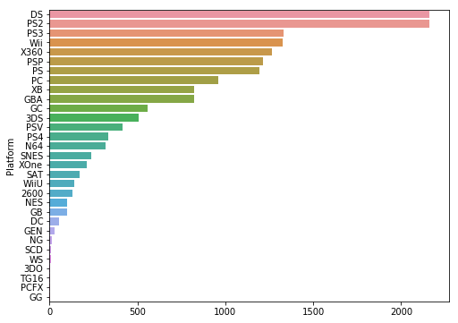

[figure not shown]

```python
platGenre = pd.crosstab(dataset.Platform,dataset.Genre)
platGenreTotal = platGenre.sum(axis=1).sort_values(ascending = False)
plt.figure(figsize=(8,6))
sns.barplot(y = platGenreTotal.index, x = platGenreTotal.values, orient='h')
plt.ylabel = "Platform"
plt.xlabel = "The amount of games"
plt.show()
platGenre['Total'] = platGenre.sum(axis=1)
popPlatform = platGenre[platGenre['Total']>1000].sort_values(by='Total', ascending = False)
neededdata = popPlatform.loc[:,:'Strategy']
maxi = neededdata.values.max()
mini = neededdata.values.min()
popPlatformfinal = popPlatform.append(pd.DataFrame(popPlatform.sum(), columns=['total']).T, ignore_index=False)
sns.set(font_scale=0.7)
plt.figure(figsize=(10,5))
sns.heatmap(popPlatformfinal, vmin = mini, vmax = maxi, annot=True, fmt="d")
plt.xticks(rotation = 90)
plt.show()
```

```python
def top(df, n = 1, column = 'Global_Sales'):
    return df.sort_values(by=column)[-n:]
```

```python
dataset.groupby(['Year'], group_keys=False).apply(top)[['Year', 'Name', 'Global_Sales', 'Genre', 'Platform', 'Publisher']]
```

|  | Year | Name | Global_Sales | Genre | Platform | Publisher |
| --- | --- | --- | --- | --- | --- | --- |
| 258 | 1980.0 | Asteroids | 4.31 | Shooter | 2600 | Atari |
| 239 | 1981.0 | Pitfall! | 4.50 | Platform | 2600 | Activision |
| 89 | 1982.0 | Pac-Man | 7.81 | Puzzle | 2600 | Atari |
| 421 | 1983.0 | Baseball | 3.20 | Sports | NES | Nintendo |
| 9 | 1984.0 | Duck Hunt | 28.31 | Shooter | NES | Nintendo |
| 1 | 1985.0 | Super Mario Bros. | 40.24 | Platform | NES | Nintendo |
| 127 | 1986.0 | The Legend of Zelda | 6.51 | Action | NES | Nintendo |
| 251 | 1987.0 | Zelda II: The Adventure of Link | 4.38 | Adventure | NES | Nintendo |
| 22 | 1988.0 | Super Mario Bros. 3 | 17.28 | Platform | NES | Nintendo |
| 5 | 1989.0 | Tetris | 30.26 | Puzzle | GB | Nintendo |
| 18 | 1990.0 | Super Mario World | 20.61 | Platform | SNES | Nintendo |
| 231 | 1991.0 | The Legend of Zelda: A Link to the Past | 4.61 | Action | SNES | Nintendo |
| 50 | 1992.0 | Super Mario Land 2: 6 Golden Coins | 11.18 | Adventure | GB | Nintendo |
| 57 | 1993.0 | Super Mario All-Stars | 10.55 | Platform | SNES | Nintendo |
| 71 | 1994.0 | Donkey Kong Country | 9.30 | Platform | SNES | Nintendo |
| 187 | 1995.0 | Donkey Kong Country 2: Diddy's Kong Quest | 5.15 | Platform | SNES | Nintendo |
| 4 | 1996.0 | Pokemon Red/Pokemon Blue | 31.37 | Role-Playing | GB | Nintendo |
| 52 | 1997.0 | Gran Turismo | 10.95 | Racing | PS | Sony Computer Entertainment |
| 30 | 1998.0 | Pokémon Yellow: Special Pikachu Edition | 14.64 | Role-Playing | GB | Nintendo |
| 12 | 1999.0 | Pokemon Gold/Pokemon Silver | 23.10 | Role-Playing | GB | Nintendo |
| 132 | 2000.0 | Pokémon Crystal Version | 6.39 | Role-Playing | GB | Nintendo |
| 28 | 2001.0 | Gran Turismo 3: A-Spec | 14.98 | Racing | PS2 | Sony Computer Entertainment |
| 24 | 2002.0 | Grand Theft Auto: Vice City | 16.15 | Action | PS2 | Take-Two Interactive |
| 104 | 2003.0 | Need for Speed Underground | 7.20 | Racing | PS2 | Electronic Arts |
| 17 | 2004.0 | Grand Theft Auto: San Andreas | 20.81 | Action | PS2 | Take-Two Interactive |
| 10 | 2005.0 | Nintendogs | 24.76 | Simulation | DS | Nintendo |
| 0 | 2006.0 | Wii Sports | 82.74 | Sports | Wii | Nintendo |
| 13 | 2007.0 | Wii Fit | 22.72 | Sports | Wii | Nintendo |
| 2 | 2008.0 | Mario Kart Wii | 35.82 | Racing | Wii | Nintendo |
| 3 | 2009.0 | Wii Sports Resort | 33.00 | Sports | Wii | Nintendo |
| 15 | 2010.0 | Kinect Adventures! | 21.82 | Misc | X360 | Microsoft Game Studios |
| 29 | 2011.0 | Call of Duty: Modern Warfare 3 | 14.76 | Shooter | X360 | Activision |
| 34 | 2012.0 | Call of Duty: Black Ops II | 14.03 | Shooter | PS3 | Activision |
| 16 | 2013.0 | Grand Theft Auto V | 21.40 | Action | PS3 | Take-Two Interactive |
| 44 | 2014.0 | Grand Theft Auto V | 11.98 | Action | PS4 | Take-Two Interactive |
| 33 | 2015.0 | Call of Duty: Black Ops 3 | 14.24 | Shooter | PS4 | Activision |
| 221 | 2016.0 | FIFA 17 | 4.77 | Sports | PS4 | Electronic Arts |
| 14390 | 2017.0 | Phantasy Star Online 2 Episode 4: Deluxe Package | 0.03 | Role-Playing | PS4 | Sega |

```python
# Даты выхода основных консолей (современных, но до выхода PS4)
release_pstwo = 2000
release_ps = 1994
release_ds = 2004
release_psthree = 2006
release_psp = 2004
release_xbox = 2001
release_xbox360 = 2005
release_gba = 2001
release_3ds = 2011
release_wii = 2006
release_n64= 1996
release_gc=2001
offm_ps=2006
offm_ps2=2012
offm_ps3=2017
offm_xb=2008
offm_x360=2016
```

```python
data = [['PS2',release_pstwo,0,0,0,'',offm_ps2],['PS',release_ps,0,0,0,'',offm_ps],['PS3',release_psthree,0,0,0,'',offm_ps3],['PSP',release_psp,0,0,0,'',2015],['XB',release_xbox,0,0,0,'',offm_xb],['X360',release_xbox360,0,0,0,'',offm_x360],['DS',release_ds,0,0,0,'',2011],['GBA',release_gba,0,0,0,'',2006],['3DS',release_3ds,0,0,0,'',2019],['Wii',release_wii,0,0,0,'',2015],['N64',release_n64,0,0,0,'',2004],['GC',release_gc,0,0,0,'',2008]]
df = pd.DataFrame(data,columns=['Console','Release','MV Title Release', 'Age_of_console', 'Sold', 'Title', 'Discontinued'])
df
```

|  | Console | Release | MV Title Release | Age_of_console | Sold | Title | Discontinued |
| --- | --- | --- | --- | --- | --- | --- | --- |
| 0 | PS2 | 2000 | 0 | 0 | 0 |  | 2012 |
| 1 | PS | 1994 | 0 | 0 | 0 |  | 2006 |
| 2 | PS3 | 2006 | 0 | 0 | 0 |  | 2017 |
| 3 | PSP | 2004 | 0 | 0 | 0 |  | 2015 |
| 4 | XB | 2001 | 0 | 0 | 0 |  | 2008 |
| 5 | X360 | 2005 | 0 | 0 | 0 |  | 2016 |
| 6 | DS | 2004 | 0 | 0 | 0 |  | 2011 |
| 7 | GBA | 2001 | 0 | 0 | 0 |  | 2006 |
| 8 | 3DS | 2011 | 0 | 0 | 0 |  | 2019 |
| 9 | Wii | 2006 | 0 | 0 | 0 |  | 2015 |
| 10 | N64 | 1996 | 0 | 0 | 0 |  | 2004 |
| 11 | GC | 2001 | 0 | 0 | 0 |  | 2008 |

```python
# Прогонка по пс2
bb=list(dataset.columns.values)
bb
y = dataset.iloc[:, 2].values
a = len(y)
dci = 0 # Цикл названия консолей
i = 0 # Рабочий цикл
tv = 0 #Количество проданных копий в млн
year = 0 #Год релиза
fl = []
demanded_consoles = np.array(['PS','PS2','PS3','PSP','GBA','DS','Wii','3DS','XB','X360', 'N64', 'GC'])
dc_len = len(demanded_consoles)
dc_len
while dci < dc_len:
    curcon = demanded_consoles[dci]
    while i < a:
        v = dataset.values[i][2]
        if v == curcon:
            m = dataset.values[i][10]
            print(m)
            if m >= tv:
                tv = m
                year = dataset.values[i][3]
                di = 0
                dlen = len(df)

                while di < dlen:
                    vdata = df.values[di][0]
                    if vdata == curcon:
                        df.set_value(di, 'MV Title Release', year)
                        df.set_value(di, 'Sold', tv)
                        df.set_value(di, 'Age_of_console', year - df.values[di][1])
                        df.set_value(di, 'Title', dataset.values[i][1])
                        i = a
                    di = di + 1

        i = i+1
    dci = dci + 1
    i = 0
    tv = 0
```

```
10.95
20.81
```

```
21.4
7.72
15.85
30.01
82.74
14.35
8.49
21.82
11.89
7.07
```

```python
df
```

|  | Console | Release | MV Title Release | Age_of_console | Sold | Title | Discontinued |
| --- | --- | --- | --- | --- | --- | --- | --- |
| 0 | PS2 | 2000 | 2004 | 4 | 20 | Grand Theft Auto: San Andreas | 2012 |
| 1 | PS | 1994 | 1997 | 3 | 10 | Gran Turismo | 2006 |
| 2 | PS3 | 2006 | 2013 | 7 | 21 | Grand Theft Auto V | 2017 |
| 3 | PSP | 2004 | 2005 | 1 | 7 | Grand Theft Auto: Liberty City Stories | 2015 |
| 4 | XB | 2001 | 2004 | 3 | 8 | Halo 2 | 2008 |
| 5 | X360 | 2005 | 2010 | 5 | 21 | Kinect Adventures! | 2016 |
| 6 | DS | 2004 | 2006 | 2 | 30 | New Super Mario Bros. | 2011 |
| 7 | GBA | 2001 | 2002 | 1 | 15 | Pokemon Ruby/Pokemon Sapphire | 2006 |
| 8 | 3DS | 2011 | 2013 | 2 | 14 | Pokemon X/Pokemon Y | 2019 |
| 9 | Wii | 2006 | 2006 | 0 | 82 | Wii Sports | 2015 |
| 10 | N64 | 1996 | 1996 | 0 | 11 | Super Mario 64 | 2004 |
| 11 | GC | 2001 | 2001 | 0 | 7 | Super Smash Bros. Melee | 2008 |

## На первый взгляд, данные никак не связаны между собой, однако это не так. В таблице выше присутствуют несколько групп консолей: 6-7 поколение консолей (PS2,XBOX360,PS3,XBOX), портативные консоли (PSP,DS,GBA,3DS) и стационарные консоли от Nintendo (Wii, N64)

### Такая разница в возрасте консоли, когда выходит самый продаваемый тайтл, обусловлена различным подходом компаний к библиотеке своих игр. Так, консоли от Nintendo выходят вместе с продаваемыми миллионными тиражами эксклюзивами, портативные консоли просто демонстрируют довольно короткий период между релизом девайса и релизом самой продаваемой игры на нем, а представители Sony/Microsoft как правило, получают самый продаваемый тайтл в середине жизненного цикла консоли (PS3 в данном случае - исключение, поскольку GTA V изменило эту статистику)

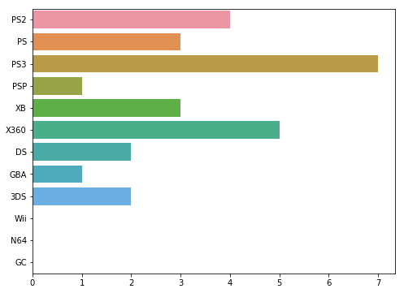

```python
platGenre = df.Console
platGenreTotal = df.Age_of_console
#platGenreTotal = platGenreTotal.sort_values(ascending = False)
plt.figure(figsize=(8,6))
sns.barplot(y = platGenre.values, x = platGenreTotal.values, orient='h')
plt.ylabel = "Console"
plt.xlabel = "Age of console"
plt.show()
```

На графике хорошо видны различия между группами

```python
r_array = []
i = 0
a = len(df)
while i < a:
    if df.values[i][0] == 'PS2':
        r_array.append(df.values[i][3])
    elif df.values[i][0] == 'PS3':
        r_array.append(df.values[i][3])
    elif df.values[i][0] == 'PS':
        r_array.append(df.values[i][3])
    elif df.values[i][0] == 'XB':
        r_array.append(df.values[i][3])
    elif df.values[i][0] == 'X360':
        r_array.append(df.values[i][3])
    i = i + 1
np.mean(r_array)
```

```
4.4
```

Соответственно, средний возраст стационарной консоли Sony/Microsoft на момент выхода самой продаваемой игры - 4.4 года

Зададим дополнительный вопрос - а можно ли предсказать конец жизненного цикла консоли, зная дату релиза (предположительно) самой продаваемой игры на ней?

```python
df = df.assign(Life_Cycle=df['Discontinued'])
i = 0
a = len(df)
while i < a:
    df.set_value(i, 'Life_Cycle', df.values[i][6] - df.values[i][1])
    i = i + 1
df
```

|  | Console | Release | MV Title Release | Age_of_console | Sold | Title | Discontinued | Life_Cycle |
| --- | --- | --- | --- | --- | --- | --- | --- | --- |
| 0 | PS2 | 2000 | 2004 | 4 | 20 | Grand Theft Auto: San Andreas | 2012 | 12 |
| 1 | PS | 1994 | 1997 | 3 | 10 | Gran Turismo | 2006 | 12 |
| 2 | PS3 | 2006 | 2013 | 7 | 21 | Grand Theft Auto V | 2017 | 11 |
| 3 | PSP | 2004 | 2005 | 1 | 7 | Grand Theft Auto: Liberty City Stories | 2015 | 11 |
| 4 | XB | 2001 | 2004 | 3 | 8 | Halo 2 | 2008 | 7 |
| 5 | X360 | 2005 | 2010 | 5 | 21 | Kinect Adventures! | 2016 | 11 |
| 6 | DS | 2004 | 2006 | 2 | 30 | New Super Mario Bros. | 2011 | 7 |
| 7 | GBA | 2001 | 2002 | 1 | 15 | Pokemon Ruby/Pokemon Sapphire | 2006 | 5 |
| 8 | 3DS | 2011 | 2013 | 2 | 14 | Pokemon X/Pokemon Y | 2019 | 8 |
| 9 | Wii | 2006 | 2006 | 0 | 82 | Wii Sports | 2015 | 9 |
| 10 | N64 | 1996 | 1996 | 0 | 11 | Super Mario 64 | 2004 | 8 |
| 11 | GC | 2001 | 2001 | 0 | 7 | Super Smash Bros. Melee | 2008 | 7 |

```python
df = df.drop([6,3,7,8,9,10,11], axis = 0)
```

```python
df
```

|  | Console | Release | MV Title Release | Age_of_console | Sold | Title | Discontinued | Life_Cycle |
| --- | --- | --- | --- | --- | --- | --- | --- | --- |
| 0 | PS2 | 2000 | 2004 | 4 | 20 | Grand Theft Auto: San Andreas | 2012 | 12 |
| 1 | PS | 1994 | 1997 | 3 | 10 | Gran Turismo | 2006 | 12 |
| 2 | PS3 | 2006 | 2013 | 7 | 21 | Grand Theft Auto V | 2017 | 11 |
| 4 | XB | 2001 | 2004 | 3 | 8 | Halo 2 | 2008 | 7 |
| 5 | X360 | 2005 | 2010 | 5 | 21 | Kinect Adventures! | 2016 | 11 |

```python
pX = df.iloc[:, 3].values
X = pX.reshape(-1, 1)
y = df.iloc[:, 7].values
y.reshape(-1,1)
X
```

```
array([[4],
       [3],
       [7],
       [3],
       [5]], dtype=int64)
```

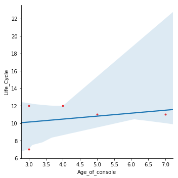

```python
sns.lmplot(x = "Age_of_console", y = "Life_Cycle", data = df, markers = ".", scatter_kws = {"color":"red"})
plt.show()
```

```python
from sklearn.externals.six import StringIO
from sklearn import tree
from IPython.display import Image
import pydotplus as pydot
targetColumn = ['Life_Cycle']
FeatureColumns_dt2 = ['Age_of_console']
y = df[targetColumn].values
X = df[FeatureColumns_dt2].values
from sklearn.model_selection import train_test_split
X_train, X_test, y_train, y_test = train_test_split(X, y, test_size = 1/3, random_state = 1)
clf_tree = DecisionTreeClassifier(criterion='entropy', max_depth=5, random_state=0)
clf_tree.fit(X_train, y_train)
predicted = clf_tree.score(X_test, y_test)
print(predicted)
```

```
0.5
```

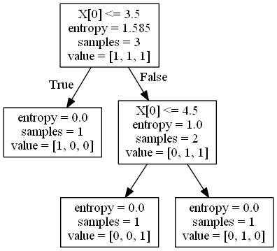

```python
dot_data = StringIO()
tree.export_graphviz(clf_tree, out_file=dot_data)
graph = pydot.graph_from_dot_data(dot_data.getvalue())
Image(graph.create_png())
```

### Мы смогли увидеть разделение консолей на группы по дате выхода эксклюзивов и нашли средний возраст консолей от Sony/Microsoft, когда выходят самые продаваемые тайтлы. Однако данных пока что слишком мало, чтобы на основе этих данных делать вывод и продолжительности жизненного цикла консоли.